# Modulus of Permutations

### Information

Student: Vinny Sun

Graduate Mentor: Ngoc Huy Truong  
Faculty Mentor: Pietro Poggi-Corradini

Funded by:  
NSF DMS 2154032  
K-State Arts & Sciences Scholarship  
K-State Scholar Development and Undergraduate Research (SDUR) Research Award

under NODE Group activities

### Items Read

Mathematics of Networks: Modulus Theory and Convex Optimization, Nathan Albin and Pietro Poggi-Corradini

Finding a Minimum Independent Dominating Set in a Permutation Graph, Mikhail J. Atallah

Maintenance of Configurations in the plane, Mark H. Overmars and Jan van Leeuwen

### Permutations

An ordering of elements

Consider the permutation of $1,\dots,5$:

$$ \pi = 2\ 1\ 4\ 5\ 3 $$

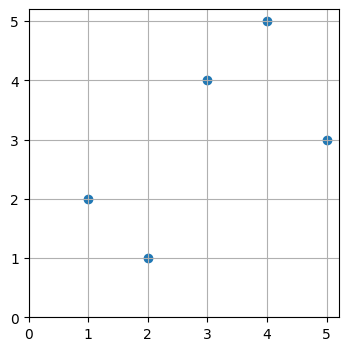

### Maximal Increasing Subsequence (MISS)

A subsequence of increasing elements in the permutation that cannot be extended

For $2\ 1\ 4\ 5\ 3$

$1\ 4\ 5$ is a MISS corresponding to indices $2\ 3\ 4$

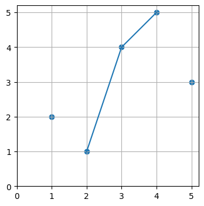

### Working towards the modulus

$\Gamma$ is a family of objects $\gamma$.

Then $\mathcal{N}$ is the *usage matrix* of objects in $\Gamma$.

For example, the entry for the previous MISS would be [0 1 1 1 0]

Now we want all MISS. This is a subgraph of all up and right paths

```
[(1, 3), (1, 4), (1, 5), (2, 3), (2, 4), (2, 5), (3, 4)]
```

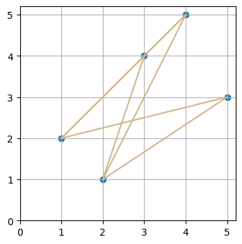

We just need to remove the "shortcuts"

```
def in_box(t, s):
    i, j = t[0], t[1]
    if any(s[x] < s[j] and s[x] > s[i] for x in range(i + 1, j)):
        return True
    return False
```

```
[(1, 3), (1, 5), (2, 3), (2, 5), (3, 4)]
```

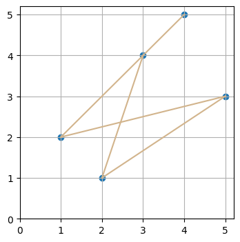

#### How can we generate all of these MISS in a usage matrix?

Essentially depth first search (code if interested)

```
def find_sources(s):
    return [i for i, element in enumerate(s) if all(element < x for x in s[:i])]

def recursive_function(s):
    m = np.empty((0, len(s)))
    def recurse(s, x, row):
        row[x] = 1
        greater = []
        for i in range(x, len(s)):
            if s[i] > s[x] and all(s[j] > s[i] for j in greater):
                greater.append(i)
        if len(greater) == 0:
            nonlocal m
            m = np.concatenate((m, [row]), axis=0)
            return
        for element in greater:
            recurse(s, element, row.copy())

    for source in find_sources(s):
        recurse(s, source, np.zeros(len(s)))

    return m
```

```
usage matrix from recursive function:
[[1. 0. 1. 1. 0.]
 [1. 0. 0. 0. 1.]
 [0. 1. 1. 1. 0.]
 [0. 1. 0. 0. 1.]]
```

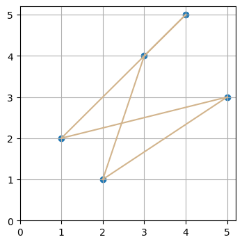

We can also do this with larger permutations

$$ \pi = 7\ 3\ 1\ 17\ 10\ 18\ 9\ 20\ 6\ 12\ 16\ 13\ 2\ 8\ 19\ 4\ 15\ 11\ 14\ 5 $$

```
71 rows in usage matrix
```

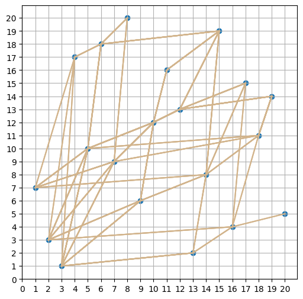

### Modulus

Now we have an efficient way to generate all MISS (we have our objects)

We must define $\rho \in \mathbb{R}_{+}^{N}$ (essentially node weights) and the $\rho$-length as $\ell_\rho(\gamma) := \sum_{j=1}^{N} \mathcal{N}(\gamma, j)\rho(j)$ (the "cost" of a MISS)

And admissibility: $\rho$ is admissible for $\Gamma$ if $\ell_\rho(\gamma) \geq 1 \: \forall \: \gamma \in \Gamma$

Now we can define the *p-Modulus* $\text{Mod}(\Gamma) = \inf\limits_{\rho \in \text{Adm}(\Gamma)} \sum_{j=1}^{N} \rho(j)^p$

### Two algorithms for computing modulus:

- Basic Algorithm
- Plus-1 Algorithm

basic algo

```
while True:
    usage_row, lightest_value = lightest_path(pi, rho)

    if lightest_value >= 1:
        break

    N = add_constraint(N, usage_row)

    mod, rho = modulus(N, p)
```

plus 1

```
for _ in range(num_iter):
    _, usage_row, lightest_value = lightest_path(pi, eta)
    for x in np.nonzero(usage_row):
        eta[x] += 1

eta = eta / num_iter
mod = 1. / sum(i ** 2 for i in eta)
```

Both of these algorithms need the *lightest* MISS given some node weights  
This is an easy change

Given our larger example from before $$ \pi = 7\ 3\ 1\ 17\ 10\ 18\ 9\ 20\ 6\ 12\ 16\ 13\ 2\ 8\ 19\ 4\ 15\ 11\ 14\ 5 $$ and node weights $$ w = .1\ .3\ .4\ .2\ .5\ .7\ .2\ .3\ .9\ .6\ .3\ .6\ .1\ .2\ .4\ .3\ .4\ .8\ .9\ .2\ $$

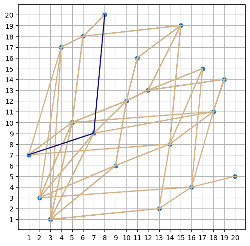

### Now we are ready to see the algorithms in action

Starting with the 1-modulus

```
(0.9999999999999993, array([0.2, 0.2, 0.2, 0.2, 0.2]))
```

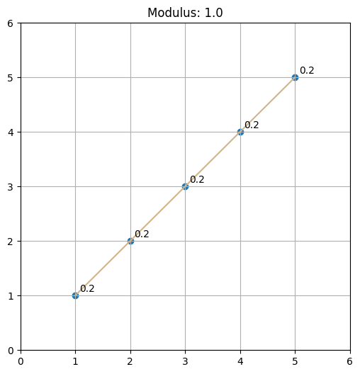

```
(1.9999999996111701, array([0.4000072, 0.4000072, 0.2999964, 0.2999964, 0.5999928]))
```

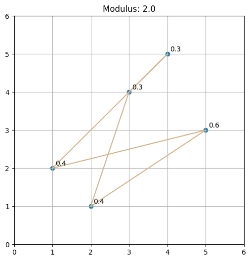

```
(1.0000000000156535, array([1.04243194e-11, 1.04242620e-11, 1.00000000e+00, 1.04242507e-11,
       1.04242620e-11]))
```

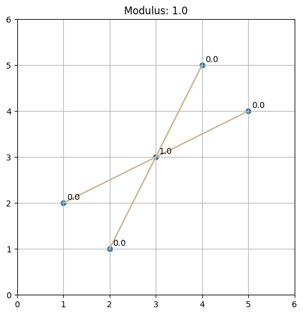

### Looking at both algorithms (2-modulus)

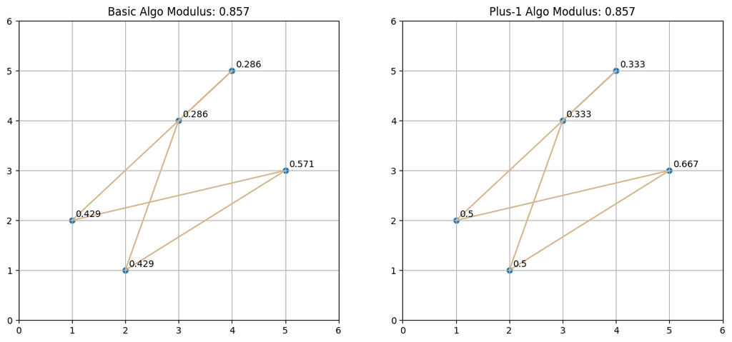

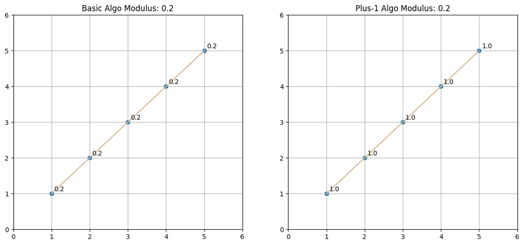

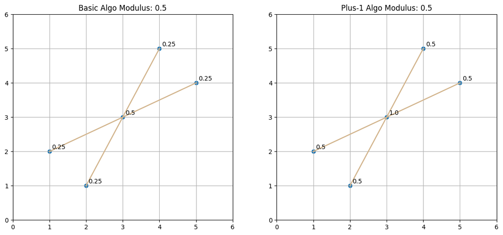

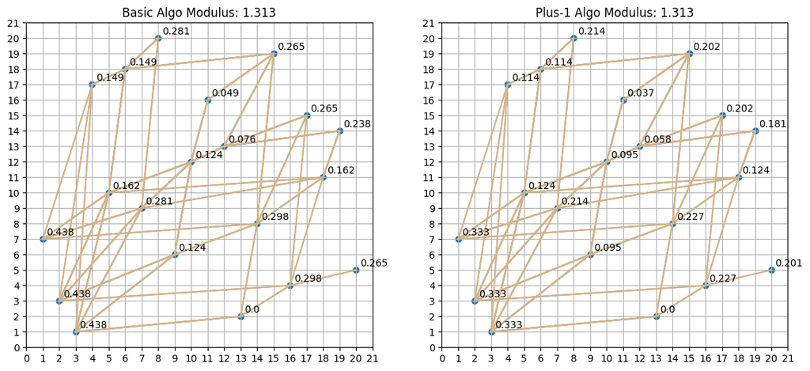

### Observation

The Basic Algorithm computes $\rho^*$ - the optimal density

The Plus-1 Algorithm computes $\eta^*$ where $\eta(v) = \mathbb{P}(v \in \text{MISS})$

$\eta^* = \frac{\rho^*}{\|\rho^*\|^2}$

$\text{Mod} = (\sum_{i \in \eta^*} \eta(i)^2)^{-1}$

### Possible usages

- MISS are commonly studied
- edge-modulus generalizes graph concepts

### Future Work

- fully implement and use algorithm detailed in Atallah et al.
- try random permuatations and analyze results
- explore modulus of Dominating Independent Sets

### Repo

[figure not shown]

Also if you're interested in learning more, take MATH 725/726